# Module 8: Cluster Analysis

The following tutorial contains Python examples for solving cluster analysis problems. You should refer to Chapters 7 and 8 of the "Introduction to Data Mining" book to understand some of the concepts introduced in this tutorial. The notebook can be downloaded from http://www.cse.msu.edu/~ptan/dmbook/tutorials/tutorial8/tutorial8.ipynb.

Cluster analysis seeks to partition the input data into groups of closely related instances so that instances that belong to the same cluster are more similar to each other than to instances that belong to other clusters. In this tutorial, we will provide examples of using different clustering techniques provided by the scikit-learn library package.

Read the step-by-step instructions below carefully. To execute the code, click on the corresponding cell and press the SHIFT-ENTER keys simultaneously.

**See your tasks marked as 'EXERCISE' to apply the code to the airquality.csv files.**

Add your reflective comments directly in with the exercise markdown block.

## 8.1 K-means Clustering

The k-means clustering algorithm represents each cluster by its corresponding cluster centroid. The algorithm would partition the input data into *k* disjoint clusters by iteratively applying the following two steps:

1. Form *k* clusters by assigning each instance to its nearest centroid.
2. Recompute the centroid of each cluster.

In this section, we perform k-means clustering on a toy example of movie ratings dataset. We first create the dataset as follows.

**EXERCISE: code has been added as comments to input the airquality.csv data set and clean it up. You can adjust the comments and code to prepare airQ to be the data set to identify clusters.**

```python
import pandas as pd

ratings = [['john',5,5,2,1],['mary',4,5,3,2],['bob',4,4,4,3],['lisa',2,2,4,5],['lee',1,2,3,4],['harry',2,1,5,5]]
titles = ['user','Jaws','Star Wars','Exorcist','Omen']
movies = pd.DataFrame(ratings,columns=titles)
print(movies)
airQ = pd.read_csv('/Users/Charley/Dropbox/Charley/Juniata/Data Science Masters/Data Mining/airquality.csv')
print(airQ)
airQ =  airQ.dropna();
airQ = airQ.drop(['Month','Day'],axis=1)
print(airQ)
```

```
    user  Jaws  Star Wars  Exorcist  Omen
0   john     5          5         2     1
1   mary     4          5         3     2
2    bob     4          4         4     3
3   lisa     2          2         4     5
4    lee     1          2         3     4
5  harry     2          1         5     5
      Id  Ozone  Solar.R  Wind  Temp  Month  Day
0      1   41.0    190.0   7.4    67      5    1
1      2   36.0    118.0   8.0    72      5    2
2      3   12.0    149.0  12.6    74      5    3
3      4   18.0    313.0  11.5    62      5    4
4      5    NaN      NaN  14.3    56      5    5
..   ...    ...      ...   ...   ...    ...  ...
148  149   30.0    193.0   6.9    70      9   26
```

[output cut: 20 more lines]

In this example dataset, the first 3 users liked action movies (Jaws and Star Wars) while the last 3 users enjoyed horror movies (Exorcist and Omen). Our goal is to apply k-means clustering on the users to identify groups of users with similar movie preferences.

**EXERCISE: modify the code below to apply the K-means to your airquality dataset**

```python
from sklearn import cluster

data = airQ.drop('Id',axis=1)
k_means = cluster.KMeans(n_clusters=4, max_iter=50, random_state=1)
k_means.fit(data)
labels = k_means.labels_
pd.DataFrame(labels, index=airQ.Id, columns=['Cluster ID'])
```

| Id | Cluster ID |
| --- | --- |
| 1 | 3 |
| 2 | 3 |
| 3 | 3 |
| 4 | 0 |
| 7 | 0 |
| ... | ... |
| 148 | 1 |
| 149 | 3 |
| 151 | 3 |
| 152 | 3 |
| 153 | 0 |

111 rows × 1 columns

**EXERCISE: be sure your clusters are characterized**

EXERCISE: set K=4 or some other value than 2 above to be sure you are getting different clusters.

```python
centroids = k_means.cluster_centers_
pd.DataFrame(centroids,columns=data.columns)
```

|  | Ozone | Solar.R | Wind | Temp |
| --- | --- | --- | --- | --- |
| 0 | 33.829268 | 268.463415 | 10.880488 | 76.146341 |
| 1 | 19.851852 | 50.407407 | 11.437037 | 71.296296 |
| 2 | 94.304348 | 217.130435 | 6.460870 | 88.956522 |
| 3 | 29.050000 | 157.550000 | 9.990000 | 77.100000 |

**EXTRA CREDIT EXERCISE: you may adjust the test data to assign clusters to your test data.**

```python
import numpy as np

testData = np.array([[4,5,1,2],[3,2,4,4],[2,3,4,1],[3,2,3,3],[5,4,1,4]])
labels = k_means.predict(testData)
labels = labels.reshape(-1,1)
usernames = np.array(['paul','kim','liz','tom','bill']).reshape(-1,1)
cols = movies.columns.tolist()
cols.append('Cluster ID')
newusers = pd.DataFrame(np.concatenate((usernames, testData, labels), axis=1),columns=cols)
newusers
```

[output not shown]

To determine the number of clusters in the data, we can apply k-means with varying number of clusters from 1 to 6 and compute their corresponding sum-of-squared errors (SSE) as shown in the example below. The "elbow" in the plot of SSE versus number of clusters can be used to estimate the number of clusters.

**EXERCISE: When applied to your airquality data, how many clusters should you go for?**

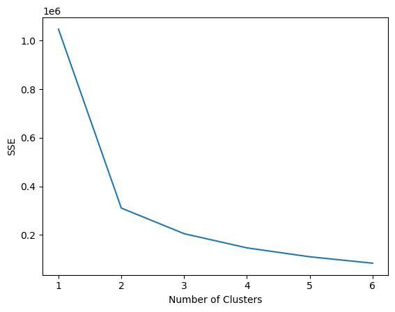

```python
import matplotlib.pyplot as plt
%matplotlib inline

numClusters = [1,2,3,4,5,6]
SSE = []
for k in numClusters:
    k_means = cluster.KMeans(n_clusters=k)
    k_means.fit(data)
    SSE.append(k_means.inertia_)

plt.plot(numClusters, SSE)
plt.xlabel('Number of Clusters')
plt.ylabel('SSE')
```

For the airquality data, I should go for 2 clusters.

## 8.2 Hierarchical Clustering

This section demonstrates examples of applying hierarchical clustering to the vertebrate dataset used in Module 6 (Classification). Specifically, we illustrate the results of using 3 hierarchical clustering algorithms provided by the Python scipy library: (1) single link (MIN), (2) complete link (MAX), and (3) group average. Other hierarchical clustering algorithms provided by the library include centroid-based and Ward's method.

**EXERCISE: Append 5 more instances to the the data set, either in your data file or in Python. Try to think of exotic examples, but accurate. A couple might not necessarily be a vertebrate. Report how your data changes the results. You should compare your additions to the original dataset. IF you to add a new class, consider changing the number of clusters. Review how the additional data changes the other variations of hierarchical clustering below (MIN, MAX, etc)**

```python
import pandas as pd

verte = pd.read_csv('/Users/Charley/Dropbox/Charley/Juniata/Data Science Masters/Data Mining/vertebrate.csv',header='infer')
data = verte.drop('Name',axis=1)
data = data.drop ('Class',axis=1)
print(verte)
nverte = pd.read_csv('/Users/Charley/Dropbox/Charley/Juniata/Data Science Masters/Data Mining/newvert.csv',header='infer')
ndata = nverte.drop('Name',axis=1)
ndata = ndata.drop ('Class',axis=1)
nverte
```

```
             Name  Warm-blooded  Gives Birth  Aquatic Creature  \
0           human             1            1                 0
1          python             0            0                 0
2          salmon             0            0                 1
3           whale             1            1                 1
4            frog             0            0                 1
5          komodo             0            0                 0
6             bat             1            1                 0
7          pigeon             1            0                 0
8             cat             1            1                 0
9   leopard shark             0            1                 1
10         turtle             0            0                 1
11        penguin             1            0                 1
12      porcupine             1            1                 0
13            eel             0            0                 1
```

[output cut: 18 more lines]

|  | Name | WarmBlooded | GivesBirth | AquaticCreature | AerialCreature | HasLegs | Hibernates | Class |
| --- | --- | --- | --- | --- | --- | --- | --- | --- |
| 0 | human | 1 | 1 | 0 | 0 | 1 | 0 | mammals |
| 1 | python | 0 | 0 | 0 | 0 | 0 | 1 | reptiles |
| 2 | salmon | 0 | 0 | 1 | 0 | 0 | 0 | fishes |
| 3 | whale | 1 | 1 | 1 | 0 | 0 | 0 | mammals |
| 4 | frog | 0 | 0 | 1 | 0 | 1 | 1 | amphibians |
| 5 | komodo | 0 | 0 | 0 | 0 | 1 | 0 | reptiles |
| 6 | bat | 1 | 1 | 0 | 1 | 1 | 1 | mammals |
| 7 | pigeon | 1 | 0 | 0 | 1 | 1 | 0 | birds |
| 8 | cat | 1 | 1 | 0 | 0 | 1 | 0 | mammals |
| 9 | leopard shark | 0 | 1 | 1 | 0 | 0 | 0 | fishes |
| 10 | turtle | 0 | 0 | 1 | 0 | 1 | 0 | reptiles |
| 11 | penguin | 1 | 0 | 1 | 0 | 1 | 0 | birds |
| 12 | porcupine | 1 | 1 | 0 | 0 | 1 | 1 | mammals |
| 13 | eel | 0 | 0 | 1 | 0 | 0 | 0 | fishes |
| 14 | salamander | 0 | 0 | 1 | 0 | 1 | 1 | amphibians |
| 15 | spider | 0 | 0 | 0 | 0 | 1 | 0 | arachnids |
| 16 | tiger | 1 | 1 | 0 | 0 | 1 | 0 | mammals |
| 17 | crow | 1 | 0 | 0 | 1 | 1 | 0 | birds |
| 18 | monkey | 1 | 1 | 0 | 0 | 1 | 0 | mammals |
| 19 | bass | 0 | 0 | 1 | 0 | 0 | 0 | fishes |

```python
k_means = cluster.KMeans(n_clusters=6, max_iter=5, random_state=1)
k_means.fit(data)
labels = k_means.labels_
cols = verte.columns.tolist()
cols.append('Cluster ID')
#newverte = pd.DataFrame(np.concatenate((Name, verte, labels), axis=1),columns=cols)
print(pd.DataFrame(labels, index=verte.Name, columns=['Cluster ID']))
nk_means = cluster.KMeans(n_clusters=6, max_iter=5, random_state=1)
nk_means.fit(ndata)
nlabels = nk_means.labels_
ncols = nverte.columns.tolist()
ncols.append('Cluster ID')
pd.DataFrame(nlabels, index=nverte.Name, columns=['Cluster ID'])
```

```
               Cluster ID
Name
human                   3
python                  2
salmon                  5
whale                   0
frog                    2
komodo                  1
bat                     4
pigeon                  4
cat                     3
leopard shark           0
turtle                  1
penguin                 1
porcupine               3
eel                     5
salamander              2
```

| Name | Cluster ID |
| --- | --- |
| human | 1 |
| python | 0 |
| salmon | 2 |
| whale | 2 |
| frog | 4 |
| komodo | 0 |
| bat | 5 |
| pigeon | 3 |
| cat | 1 |
| leopard shark | 2 |
| turtle | 4 |
| penguin | 4 |
| porcupine | 5 |
| eel | 2 |
| salamander | 4 |
| spider | 0 |
| tiger | 1 |
| crow | 3 |
| monkey | 1 |
| bass | 2 |

In my larger dataset, unlike the original, porcupines are not grouped with humans and cats but tigers and monkeys are; pythons are no longer grouped with frogs and salamanders and the frogs and salamanders have been added to the turtles and penguins group, which no longer includes komodos; salmons and eels are still grouped together but they have been combined with the whales and leopard sharks group, with bass also being added to the group. Bats and pigeons are no longer grouped together but rather bats are now grouped with porcupines and pigeons are now grouped with crows. Finally, pythons komodos and spiders are all now grouped together whereas none of them were grouped together previously, although spiders are new to my dataset so naturally they wouldn't have been grouped with anything in the original dataset.

### 8.2.1 Single Link (MIN)

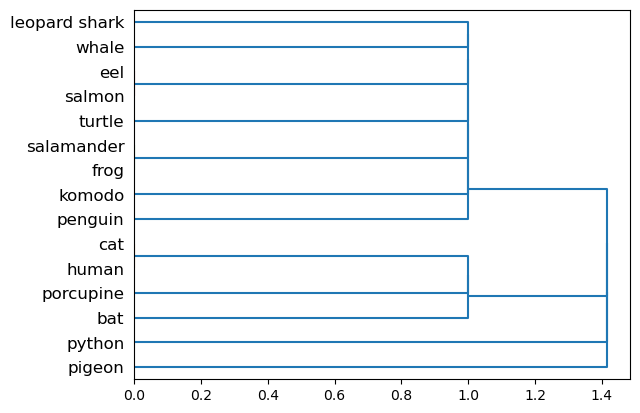

```python
from scipy.cluster import hierarchy
import matplotlib.pyplot as plt
%matplotlib inline

names = verte['Name']
Y = verte['Class']
X=data
#X = data.drop(['Name','Class'],axis=1)
Z = hierarchy.linkage(X.values, 'single')
dn = hierarchy.dendrogram(Z,labels=names.tolist(),orientation='right')
```

### 8.2.2 Complete Link (MAX)

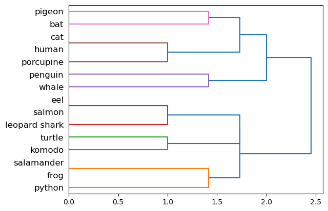

```python
Z = hierarchy.linkage(X.values, 'complete')
dn = hierarchy.dendrogram(Z,labels=names.tolist(),orientation='right')
```

### 8.3.3 Group Average

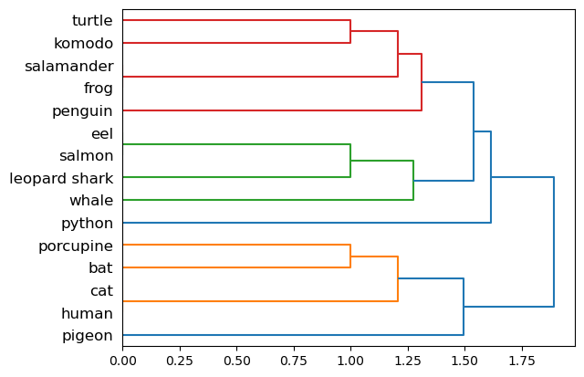

```python
Z = hierarchy.linkage(X.values, 'average')
dn = hierarchy.dendrogram(Z,labels=names.tolist(),orientation='right')
```

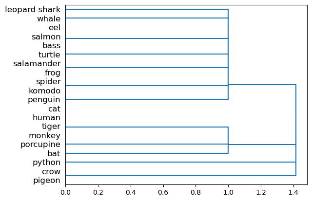

```python
names = nverte['Name']
Y = nverte['Class']
X=ndata
Z = hierarchy.linkage(X.values, 'single')
dn = hierarchy.dendrogram(Z,labels=names.tolist(),orientation='right')
```

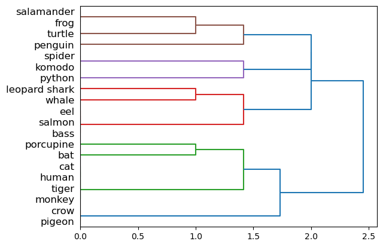

```python
Z = hierarchy.linkage(X.values, 'complete')
dn = hierarchy.dendrogram(Z,labels=names.tolist(),orientation='right')
```

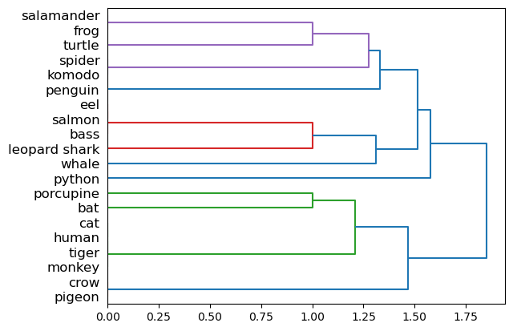

```python
Z = hierarchy.linkage(X.values, 'average')
dn = hierarchy.dendrogram(Z,labels=names.tolist(),orientation='right')
```

In the case of both of the single link dendograms whales were not successfully put in an initial subcluster with the other mammals and penguins were not successfully put in an initial subcluster with the other birds. Altogether though it doesn't seem like the addition of more animals increased or decreased the ability of the single link code to match animals to the correct class. For complete link, I think my own clustering seems a bit better than the original, but in both I can kind of make out the class groupings. Among other things I notice that the original has the amphibians a bit closer to the reptiles, but neither have all three reptiles in an initial subcluster together. The original also has bats and pigeons together in one of the initial subclusters while mine has them merged a bit later on. For my group average clustering I notice that the reptiles are completely broken up initially whereas the original at least has turtle and komodo together.

## 8.3 Density-Based Clustering

Density-based clustering identifies the individual clusters as high-density regions that are separated by regions of low density. DBScan is one of the most popular density based clustering algorithms. In DBScan, data points are classified into 3 types---core points, border points, and noise points---based on the density of their local neighborhood. The local neighborhood density is defined according to 2 parameters: radius of neighborhood size (eps) and minimum number of points in the neighborhood (min_samples).

For this approach, we will use a noisy, 2-dimensional dataset originally created by Karypis et al. [1] for evaluating their proposed CHAMELEON algorithm. The example code shown below will load and plot the distribution of the data.

**EXERCISE: Experiment with the two available parameters, number of clusters and eps, where appropriate, and report your observations.**

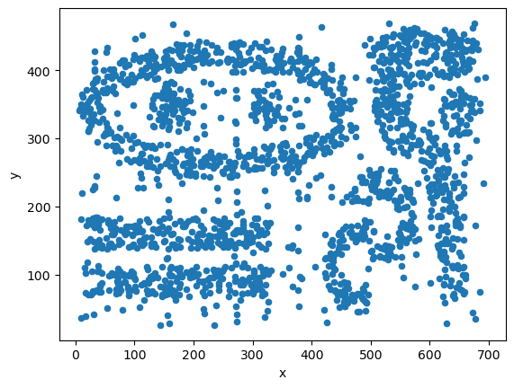

```python
import pandas as pd
import numpy as np

data = pd.read_csv('/Users/Charley/Dropbox/Charley/Juniata/Data Science Masters/Data Mining/chameleon.txt', delimiter=' ', names=['x','y'])
data.plot.scatter(x='x',y='y')
```

We apply the DBScan clustering algorithm on the data by setting the neighborhood radius (eps) to 15.5 and minimum number of points (min_samples) to be 5. The clusters are assigned to IDs between 0 to 8 while the noise points are assigned to a cluster ID equals to -1.

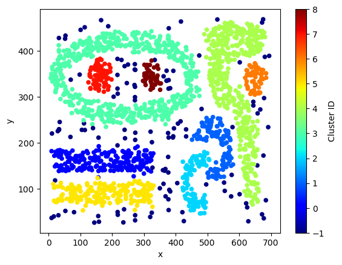

```python
from sklearn.cluster import DBSCAN

db = DBSCAN(eps=15.5, min_samples=5).fit(data)
core_samples_mask = np.zeros_like(db.labels_, dtype=bool)
core_samples_mask[db.core_sample_indices_] = True
labels = pd.DataFrame(db.labels_,columns=['Cluster ID'])
result = pd.concat((data,labels), axis=1)
result.plot.scatter(x='x',y='y',c='Cluster ID', colormap='jet')
```

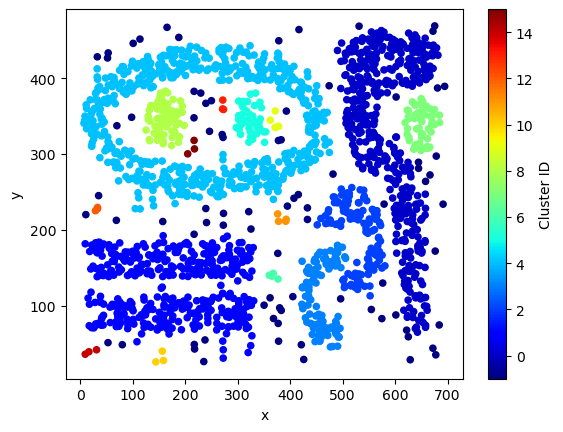

```python
from sklearn.cluster import DBSCAN

db = DBSCAN(eps=15.5, min_samples=3).fit(data)
core_samples_mask = np.zeros_like(db.labels_, dtype=bool)
core_samples_mask[db.core_sample_indices_] = True
labels = pd.DataFrame(db.labels_,columns=['Cluster ID'])
result = pd.concat((data,labels), axis=1)
result.plot.scatter(x='x',y='y',c='Cluster ID', colormap='jet')
```

Increasing eps while leaving min_samples the same causes fewer clusters to be identified, and surrounding stuctures start to get merged until all the points are part of one cluster. Increasing min_samples while leaving eps the same tends to cause a lot of unique and seemingly arbitrary clusters that don't tell us anything meaningful start to emerge within all the main structures. I did also find that you can leave eps at 15.5 and set min_samples down to 3 while still being able to make out most of the main structures, with the catch seeming to be that fewer points are correctly identified as noise.

## 8.4 Spectral Clustering

One of the main limitations of the k-means clustering algorithm is its tendency to seek for globular-shaped clusters. Thus, it does not work when applied to datasets with arbitrary-shaped clusters or when the cluster centroids overlapped with one another. Spectral clustering can overcome this limitation by exploiting properties of the similarity graph to overcome such limitations. To illustrate this, consider the following two-dimensional datasets.

**EXERCISE: Experiment with the available parameters, number of clusters etc., where appropriate, and report your observations.**

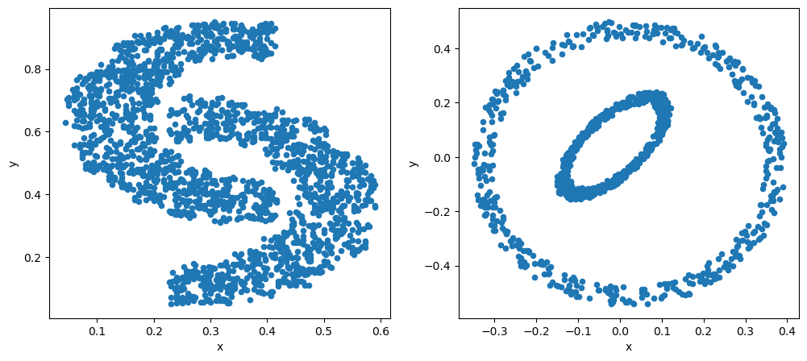

```python
import pandas as pd

data1 = pd.read_csv('/Users/Charley/Dropbox/Charley/Juniata/Data Science Masters/Data Mining/2d_data.txt', delimiter=' ', names=['x','y'])
data2 = pd.read_csv('/Users/Charley/Dropbox/Charley/Juniata/Data Science Masters/Data Mining/elliptical.txt', delimiter=' ', names=['x','y'])

fig, (ax1,ax2) = plt.subplots(nrows=1, ncols=2, figsize=(12,5))
data1.plot.scatter(x='x',y='y',ax=ax1)
data2.plot.scatter(x='x',y='y',ax=ax2)
```

Below, we demonstrate the results of applying k-means to the datasets (with k=2).

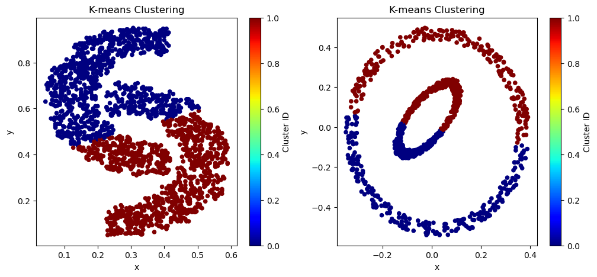

```python
from sklearn import cluster

k_means = cluster.KMeans(n_clusters=2, max_iter=50, random_state=1)
k_means.fit(data1)
labels1 = pd.DataFrame(k_means.labels_,columns=['Cluster ID'])
result1 = pd.concat((data1,labels1), axis=1)

k_means2 = cluster.KMeans(n_clusters=2, max_iter=50, random_state=1)
k_means2.fit(data2)
labels2 = pd.DataFrame(k_means2.labels_,columns=['Cluster ID'])
result2 = pd.concat((data2,labels2), axis=1)

fig, (ax1,ax2) = plt.subplots(nrows=1, ncols=2, figsize=(12,5))
result1.plot.scatter(x='x',y='y',c='Cluster ID',colormap='jet',ax=ax1)
ax1.set_title('K-means Clustering')
result2.plot.scatter(x='x',y='y',c='Cluster ID',colormap='jet',ax=ax2)
ax2.set_title('K-means Clustering')
```

The plots above show the poor performance of k-means clustering. Next, we apply spectral clustering to the datasets. Spectral clustering converts the data into a similarity graph and applies the normalized cut graph partitioning algorithm to generate the clusters. In the example below, we use the Gaussian radial basis function as our affinity (similarity) measure. Users need to tune the kernel parameter (gamma) value in order to obtain the appropriate clusters for the given dataset.

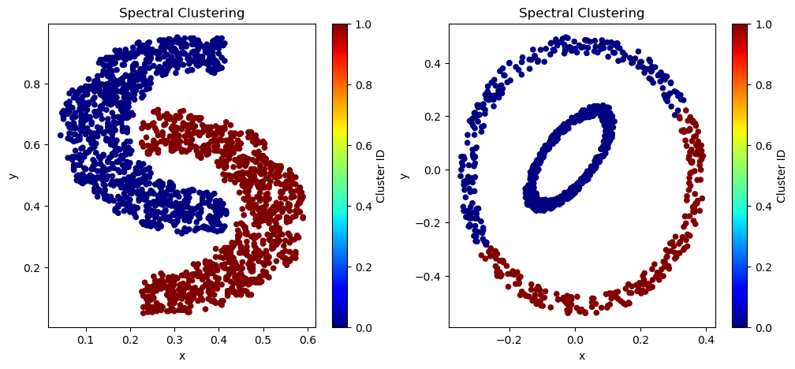

```python
from sklearn import cluster
import pandas as pd

spectral = cluster.SpectralClustering(n_clusters=2,random_state=1,affinity='rbf',gamma=5000)
spectral.fit(data1)
labels1 = pd.DataFrame(spectral.labels_,columns=['Cluster ID'])
result1 = pd.concat((data1,labels1), axis=1)

spectral2 = cluster.SpectralClustering(n_clusters=2,random_state=1,affinity='rbf',gamma=100)
spectral2.fit(data2)
labels2 = pd.DataFrame(spectral2.labels_,columns=['Cluster ID'])
result2 = pd.concat((data2,labels2), axis=1)

fig, (ax1,ax2) = plt.subplots(nrows=1, ncols=2, figsize=(12,5))
result1.plot.scatter(x='x',y='y',c='Cluster ID',colormap='jet',ax=ax1)
ax1.set_title('Spectral Clustering')
result2.plot.scatter(x='x',y='y',c='Cluster ID',colormap='jet',ax=ax2)
ax2.set_title('Spectral Clustering')
```

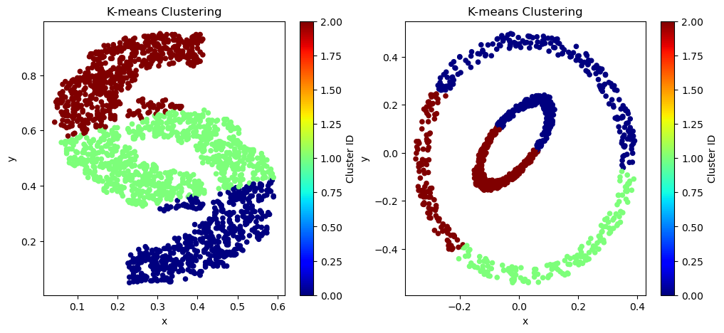

```python
from sklearn import cluster

k_means = cluster.KMeans(n_clusters=3, max_iter=50, random_state=1)
k_means.fit(data1)
labels1 = pd.DataFrame(k_means.labels_,columns=['Cluster ID'])
result1 = pd.concat((data1,labels1), axis=1)

k_means2 = cluster.KMeans(n_clusters=3, max_iter=50, random_state=1)
k_means2.fit(data2)
labels2 = pd.DataFrame(k_means2.labels_,columns=['Cluster ID'])
result2 = pd.concat((data2,labels2), axis=1)

fig, (ax1,ax2) = plt.subplots(nrows=1, ncols=2, figsize=(12,5))
result1.plot.scatter(x='x',y='y',c='Cluster ID',colormap='jet',ax=ax1)
ax1.set_title('K-means Clustering')
result2.plot.scatter(x='x',y='y',c='Cluster ID',colormap='jet',ax=ax2)
ax2.set_title('K-means Clustering')
```

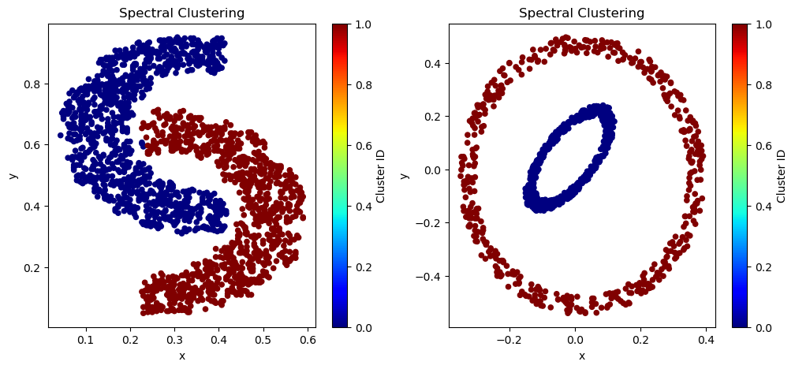

```python
from sklearn import cluster
import pandas as pd

spectral = cluster.SpectralClustering(n_clusters=2,random_state=1,affinity='rbf',gamma=2400)
spectral.fit(data1)
labels1 = pd.DataFrame(spectral.labels_,columns=['Cluster ID'])
result1 = pd.concat((data1,labels1), axis=1)

spectral2 = cluster.SpectralClustering(n_clusters=2,random_state=1,affinity='rbf',gamma=122)
spectral2.fit(data2)
labels2 = pd.DataFrame(spectral2.labels_,columns=['Cluster ID'])
result2 = pd.concat((data2,labels2), axis=1)

fig, (ax1,ax2) = plt.subplots(nrows=1, ncols=2, figsize=(12,5))
result1.plot.scatter(x='x',y='y',c='Cluster ID',colormap='jet',ax=ax1)
ax1.set_title('Spectral Clustering')
result2.plot.scatter(x='x',y='y',c='Cluster ID',colormap='jet',ax=ax2)
ax2.set_title('Spectral Clustering')
```

For k-means, increasing the number of iterations had basically no obvious improvement on either of the two plots. k=2 would give the best result; trying k=1 would just make all the points part of the same cluster and trying k>2 would lead to pointless clusterings that broke up the main patterns in the data. For spectral clustering k=2 was also optimal for the same reasons. Changing gamma seemed to have a much greater effect on the right plot than the left. For the left plot, once you increase gamma to around 2500 or above the two clusters capture basically every point of their respective structures, while for the right plot I found a gamma of 122 or higher left all points in the outer circle in a separate cluster from the points in the inner circle. Below those respective gamma values you start to get some incorrectly assigned points.

## 8.5 Summary

This tutorial illustrates examples of using different Python's implementation of clustering algorithms. Algorithms such as k-means, spectral clustering, and DBScan are designed to create disjoint partitions of the data whereas the single-link, complete-link, and group average algorithms are designed to generate a hierarchy of cluster partitions.

References: [1] George Karypis, Eui-Hong Han, and Vipin Kumar. CHAMELEON: A Hierarchical Clustering Algorithm Using Dynamic Modeling. IEEE Computer 32(8): 68-75, 1999.